# Submissions Outcomes by Gender

Dakota Murray

### Set parameters for the name and extension of the figure

```r
figure_name <- "fig_4"
figure_extension <- ".png"
path_to_data <- "https://www.dropbox.com/s/5doa2khbrs7nuyx/formatted_elife.csv?dl=1"
```

```r
# Load required packages
library(tidyverse)
library(grid)
library(gridExtra)
# setup theme
theme_dakota <- function () {
    theme_bw(base_size=10, base_family="Times") %+replace%
        theme(
            strip.background = element_blank(),
            strip.text = element_text(face = "bold"),
            plot.title = element_text(size = 11, face = "bold"),
            axis.text.x = element_text(size = 9, margin = margin(t = 5, b = 5)),
            legend.title = element_blank(),
            legend.position = "bottom"
        )
}
# converts a provided p-value into a representation that is easier to visualize
sig2ast <- function(p) { ifelse(p <= 0.0001, "****",
                                ifelse(p <= 0.001, "***",
                                       ifelse(p <= 0.01, "**",
                                              ifelse(p <= 0.05, "*",
                                                     ifelse(p < 0.1, ".", "ns")
                                              )
                                       )
                                )
                          )
}
```

### Load the required data

```r
elife <- read_csv(path_to_data)
head(elife)
```

| X1 | MSNO | ca_country | ca_gender | initial_decision | full_decision | rev1_decision | rev2_decision | appealed_any_stage | accepted | se_gender | submission_year | fa_country | la_country | fa_gender | la_gender | single_authored | ca_is_first | ca_is_last | reviewer1_gender | reviewer2_gender | reviewer3_gender | reviewer4_gender | num_reviewers | bre_gender | ca_continent | la_continent | fa_continent | se_continent | bre_continent | … |
| --- | --- | --- | --- | --- | --- | --- | --- | --- | --- | --- | --- | --- | --- | --- | --- | --- | --- | --- | --- | --- | --- | --- | --- | --- | --- | --- | --- | --- | --- | --- |
| 1 | 8764 | Argentina | F | Encourage | Revise | Accept | NA | FALSE | TRUE | F | 2015 | Argentina | Argentina | UNK | F | FALSE | FALSE | TRUE | F | F | M | NA | 4 | F | South America | South America | South America | North America | Europe | … |
| 2 | 29226 | United States | M | Encourage | Revise | NA | NA | FALSE | FALSE | M | 2017 | United States | Argentina | M | M | FALSE | TRUE | FALSE | NA | M | M | NA | 3 | M | North America | South America | North America | North America | North America | … |
| 3 | 18020 | Argentina | F | Encourage | Revise | Accept | NA | FALSE | TRUE | M | 2016 | Argentina | Argentina | F | F | FALSE | FALSE | TRUE | M | F | M | NA | 4 | M | South America | South America | South America | North America | North America | … |
| 4 | 22248 | Australia | M | Encourage | Reject | NA | NA | FALSE | FALSE | M | 2016 | Australia | Australia | F | F | FALSE | FALSE | FALSE | M | M | F | NA | 4 | M | Oceania | Oceania | Oceania | North America | Oceania | … |
| 5 | 29596 | United States | UNK | Encourage | Reject | NA | NA | FALSE | FALSE | F | 2017 | United States | Australia | UNK | M | FALSE | TRUE | FALSE | M | M | F | NA | 4 | M | North America | Oceania | North America | Europe | North America | … |
| 6 | 12248 | Australia | M | Encourage | Revise | Accept | NA | FALSE | TRUE | F | 2015 | Australia | Australia | F | M | FALSE | FALSE | TRUE | F | M | M | NA | 4 | F | Oceania | Oceania | Oceania | North America | North America | … |

## Figure 4

> Figure 4. Percentage of full submissions that were accepted, shown by the gender of the corresponding author, first author, and last author. Authors whose gender is unknown are excluded from analysis. See Figure SI.2 for an extension of this figure including submission rates, encourage rates, and overall acceptance races. Vertical error bars indicate 95th confidence intervals of the proportion of submitted, encouraged, and accepted initial and full submissions. Asterisks indicate significance level of X2 tests of independence of frequency of encourage and acceptance by gender; “*” = p < 0.05; “ns” = p > 0.05.

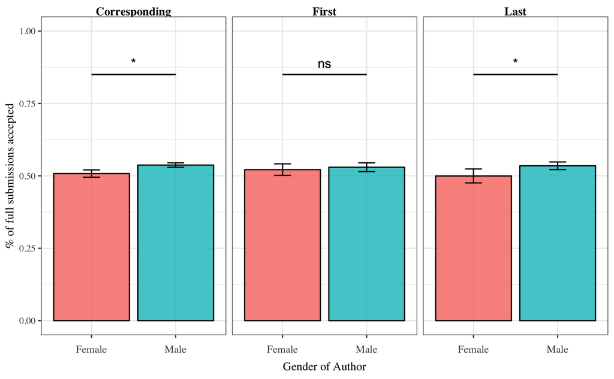

```r
# First, I'll go through and run all the tests to get signif. values. I toyed around with ways to do this more programatically, but I think that this
# manual method is perhaps the simplest
# First, test the encourage rate diffs
s <- subset(elife, initial_decision_made)
t <- table("ca_gender" = s$ca_gender, "encouraged" = s$encouraged)[1:2,]
ca_encouraged <- chisq.test(t[, 1:2])
# Difference in acceptance rates by gender of corresponding author
s <- subset(elife, initial_decision_made & (!has_full_submission | full_decision_made))
t <- table("ca_gender" = s$ca_gender, "accepted" = s$accepted)[1:2,]
ca_accepted <- chisq.test(t[, 1:2])
# Difference in encourage-acceptance rates by gender of corresponding author
s <- subset(elife, initial_decision_made & full_decision_made)
t <- table("ca_gender" = s$ca_gender, "accepted" = s$accepted)[1:2,]
ca_ea <- chisq.test(t[, 1:2])
# Difference in encourage-acceptance rates by gender of first author
s <- subset(elife, initial_decision_made & full_decision_made)
t <- table("fa_gender" = s$fa_gender, "accepted" = s$accepted)[1:2,]
fa_ea <- chisq.test(t[, 1:2])
# Difference in encourage-acceptance rates by gender of last author
s <- subset(elife, initial_decision_made & full_decision_made)
t <- table("la_gender" = s$la_gender, "accepted" = s$accepted)[1:2,]
la_ea <- chisq.test(t[, 1:2])
# Now we use the results of these tests to construct a table
measurements <- c(rep("submit_rate", 3), rep("encourage_rate", 3), rep("accept_rate", 3), rep("encourage_accept_rate", 3))
author <- rep(c("ca_gender", "fa_gender", "la_gender"), 4)
sig <- c("N/A", "N/A", "N/A", # submit rates, all NA since we don't really compare this
         sig2ast(ca_encouraged$p.value), "N/A", "N/A", # encourage rate
         sig2ast(ca_accepted$p.value), "N/A", "N/A",
         sig2ast(ca_ea$p.value), sig2ast(fa_ea$p.value), sig2ast(la_ea$p.value)
         )
sig_df <- data.frame(measure_key = factor(measurements), author_key = factor(author), sig = sig)
# Now lets save these test results for later
sig_list <- list("Corresponding author enc. rate" = ca_encouraged,
                   "Corresponding author acc. rate" = ca_accepted,
                   "Corresponding author enc-acc rate" = ca_ea,
                   "First author enc-acc rate" = fa_ea,
                   "last author enc-acc rate" = la_ea)
data <- elife %>%
  filter(initial_decision_made) %>%
  gather(author_key, value = gender, ca_gender, la_gender, fa_gender) %>%
  filter(gender %in% c('M', 'F')) %>%
  group_by(author_key) %>%
  mutate(
    # if not ocnsidering the corr. author, then the count is all full submissions, ie: for when a submission ia made
    total_papers = ifelse(author_key == "ca_gender", n(), sum(has_full_submission))
    )%>%
  group_by(author_key, gender) %>%
  summarize(
        paper_count = n(),
        accept_count = sum(accepted == TRUE, na.rm = T),
        encourage_count = sum(encouraged == TRUE),
        encourage_rate = ifelse(author_key[1] == "ca_gender", encourage_count / n(), NA),
        # this accept rate is the number of accepted papers / number of initial + full submissions
        accept_rate = ifelse(author_key[1] == "ca_gender", accept_count / sum(!has_full_submission | full_decision_made, na.rm = T), NA),
        submit_rate = n() / total_papers[1],
        # this is the number of accepted papers divided by all papers
        encourage_accept_rate = accept_count / sum(has_full_submission & full_decision_made, na.rm = T)
  ) %>%
  ungroup() %>%
  gather(measure_key, value = measurement, encourage_accept_rate) %>%
  left_join(sig_df, by = c("measure_key", "author_key")) %>%
  mutate(
    author_key = factor(author_key,
                        levels = c("ca_gender", "fa_gender", "la_gender"),
                        labels = c("ca_gender" = "Corresponding", "fa_gender" = "First", "la_gender" = "Last")
                        ),
    measure_key = factor(measure_key,
                         labels = c("submit_rate" = "Submissions", "encourage_rate" = "Enc %", "accept_rate" = "Overall Acc %", "encourage_accept_rate" = "Accept %"),
                         levels = c("submit_rate", "encourage_rate", "accept_rate", "encourage_accept_rate")),
    gender = ifelse(gender == "F", "Female", "Male"),
    standard_error = 1.96 * sqrt( (measurement * (1 - measurement)) / paper_count),
    lower = measurement - standard_error,
    upper = measurement + standard_error
  )


gender_outcomes <- data %>%
  ggplot(aes(x = gender, y = measurement, color = factor(gender), shape = factor(gender), fill = factor(gender))) +
  geom_bar(stat = "identity", alpha = 0.8, color = "black") +
  geom_errorbar(aes(ymin = lower, ymax = upper), width = 0.2, color = "black") +
  geom_text(aes(x = 1.5, y = 0.89, label = ifelse(measure_key == "Submissions", "", as.character(sig))), color = "black") +
  geom_segment(aes(x = 1, xend = 2, y = ifelse(sig != "N/A", 0.85, 1.1), yend = ifelse(sig != "N/A", 0.85, 1.1)), color = "black") +
  #facet_grid(author_key ~ measure_key) +
  facet_wrap(~author_key) +
  coord_cartesian(ylim = c(0, 1.0)) +
  theme_dakota() +
  guides(fill = F) +
  labs(
    x = "Gender of Author",
    y = "% of full submissions accepted"
  )
gender_outcomes
```

## Save the file

```r
name <- paste0("~/Dropbox/eLife/elife-analysis/figures/main/", figure_name, figure_extension)
ggsave(name, plot = gender_outcomes, height = 6, width = 7)
```

## Misc. information

Signif. test results for figure 4

```r
fig4_sig_table <- data.frame(
  test = names(sig_list),
  p.value = sapply(sig_list, function(x) x$p.value),
  n = sapply(sig_list, function(x) sum(x$observed)),
  statistic = sapply(sig_list, function(x) x$statistic),
  df = sapply(sig_list, function(x) x$parameter)
)
rownames(fig4_sig_table)<- NULL
fig4_sig_table
```

| test | p.value | n | statistic | df |
| --- | --- | --- | --- | --- |
| Corresponding author enc. rate | 0.0027793353 | 22319 | 8.9469481 | 1 |
| Corresponding author acc. rate | 0.0009315755 | 21670 | 10.9588512 | 1 |
| Corresponding author enc-acc rate | 0.0469203109 | 6188 | 3.9482438 | 1 |
| First author enc-acc rate | 0.5582417316 | 5971 | 0.3427577 | 1 |
| last author enc-acc rate | 0.0184923328 | 6505 | 5.5488974 | 1 |

### Data used to produce figure 4

```r
data %>%
  select(-sig, -lower, -upper, -standard_error) %>%
  spread(measure_key, measurement)
```

| author_key | gender | paper_count | accept_count | encourage_count | encourage_rate | accept_rate | submit_rate | Accept % |
| --- | --- | --- | --- | --- | --- | --- | --- | --- |
| Corresponding | Female | 6027 | 809 | 1733 | 0.2875394 | 0.1379134 | 0.2700390 | 0.5078468 |
| Corresponding | Male | 16292 | 2468 | 5024 | 0.3083722 | 0.1561630 | 0.7299610 | 0.5371055 |
| First | Female | 2423 | 1150 | 2369 | NA | NA | 0.3672882 | 0.5215420 |
| First | Male | 4190 | 1995 | 4098 | NA | NA | 0.6351372 | 0.5297398 |
| Last | Female | 1661 | 748 | 1624 | NA | NA | 0.2310796 | 0.4996660 |
| Last | Male | 5543 | 2678 | 5420 | NA | NA | 0.7711464 | 0.5347444 |

## Gender distirbution of gender-identified authors on full submissions at eLife, at manuscript level, includes duplicate authors

```r
full <- elife %>%
  filter(has_full_submission)
```

Of correpsonding authors

```r
full %>%
  filter(ca_gender %in% c("M", "F")) %>%
  group_by(ca_gender) %>%
  summarize(
    freq = n(),
    prop = freq / dim(full)[1]
  )
```

| ca_gender | freq | prop |
| --- | --- | --- |
| F | 1754 | 0.2438821 |
| M | 5083 | 0.7067575 |

First authors…

```r
full %>%
  filter(fa_gender %in% c("M", "F")) %>%
  group_by(fa_gender) %>%
  summarize(
    freq = n(),
    prop = freq / dim(full)[1]
  )
```

| fa_gender | freq | prop |
| --- | --- | --- |
| F | 2418 | 0.3362069 |
| M | 4179 | 0.5810623 |

And last authors

```r
full %>%
  filter(la_gender %in% c("M", "F")) %>%
  group_by(la_gender) %>%
  summarize(
    freq = n(),
    prop = freq / dim(full)[1]
  )
```

| la_gender | freq | prop |
| --- | --- | --- |
| F | 1659 | 0.2306730 |
| M | 5529 | 0.7687709 |